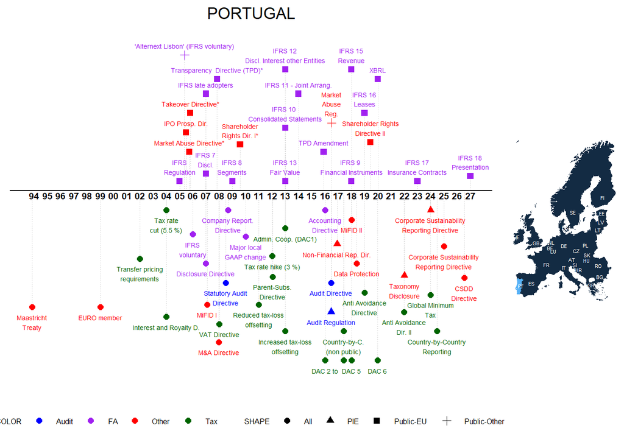

Notes: The graph depicts major regulatory changes that we identified via an extensive literature search, an online survey of mentioned authors, and other sources. Please note that the graph does not include all possible regulatory changes, e.g. minor revisions to local GAAP or tax rate changes below 3% are not included. The dates of EU Directives are based on the official transposition deadlines unless denoted with a *, in which case we included the entry-to-force date as identified in the literature. For more information, please go to [Labro and Pierk (2025)](https://link.springer.com/article/10.1007/s11142-025-09909-0). We kindly ask that you cite the paper if you use the information on this website in your research project. Do you have comments or see anything missing? Please email us!

## Regulations, Publications, Further Graphs

The tab ‘Regulations’ includes links to the regulations, gives short descriptions, and provides selective papers for further reading. If the regulation is a national transposition of an EU Directive, the link to the Directive is given. The tab ‘Number of Regulations’ shows graphically the number of regulations 8 years around the respective year (-4,-3,-2,-1,0,+1,+2,+3). The tab ‘Number of Categories” shows graphically the number of different categories 8 years around the respective year (-4,-3,-2,-1,0,+1,+2,+3). The tab ’Publications’ shows all publications that include the countries’ names and variations thereof in the title, abstract, or keywords. Similarly, the tab ‘SSRN’ shows papers of the SSRN Accouning Research Network that include the countries’ names and variations.

### Regulations

|  | Date | Milestones | Applies_to | Category | Description |
| --- | --- | --- | --- | --- | --- |
| 1 | 1993-11-01 | Maastricht Treaty | Public-EU | FA | Maastricht Treaty: Signed 'Treaty on European Union". |
| 2 | 1999-01-01 | Euro member | All Firms | FA | Euro member: Euro area member since 1 January 1999. |
| 3 | 2002-01-01 | Transfer pricing requirements | All Firms | FA | Transfer pricing requirements: Introduction of transfer pricing documentation requirements, which makes profit shifting more costly. "Corporate Income Tax Code (CITC) Art. 63(6) and (7); penalty effec… |
| 4 | 2004-01-01 | Tax rate cut (5.5 %) | All Firms | Tax | Tax rate cut (5.5 %): Portugal reduced the corporate tax rate by 5.5 percentage points (from 33 to 27.5 percent). |
| 5 | 2004-01-01 | Interest and Royalty D. | All Firms | Tax | Transpõe para a ordem jurídica interna a Directiva n.º 2003/49/CE, do Conselho, de 3 de Junho, relativa a um regime fiscal comum aplicável aos pagamentos de juros e royalties efectuados entre sociedad… |
| 6 | 2005-01-01 | IFRS Regulation | Public-EU | FA | Regulation 1606/2002: Firms listed on EU-regulated markets are required to use the International Financial Reporting Standards (IFRS) for their consolidated financial statements. Firms that use US GAA… |
| 7 | 2005-05-17 | 'Alternext Lisbon' (IFRS voluntary) | Public-Other | FA | Alternext Lisbon: The New York Stock Exchange opens the market segment 'Alternext Lisbon', in which EU regulations for EU-regulated public firms do not apply. Firms can choose to follow local GAAP or … |
| 8 | 2005-07-01 | IPO Prospectus Directive | Public-EU | Other | Ministério das Finanças e da Administração Pública-No uso das autorizações legislativas concedidas pelas Leis n.os 55/2005, de 18 de Novembro, e 56/2005, de 25 de Novembro, transpõe para a ordem juríd… |
| 9 | 2005-10-01 | Market Abuse Directive | Public-EU | Other | Presidência do Conselho de Ministros-De ter sido rectificado o Decreto-Lei n.º 52/2006, do Ministério das Finanças e da Administração Pública, que, no uso das autorizações legislativas concedidas pela… |
| 10 | 2005-10-24 | Takeover Directive | Public-EU | Other | Ministério das Finanças e da Administração Pública-Sétima alteração ao Código dos Valores Mobiliários, aprovado pelo Decreto-Lei n.º 486/99, de 13 de Novembro, que procede à transposição para a ordem … |

[output cut: 51 more lines]

### Number of Regulations

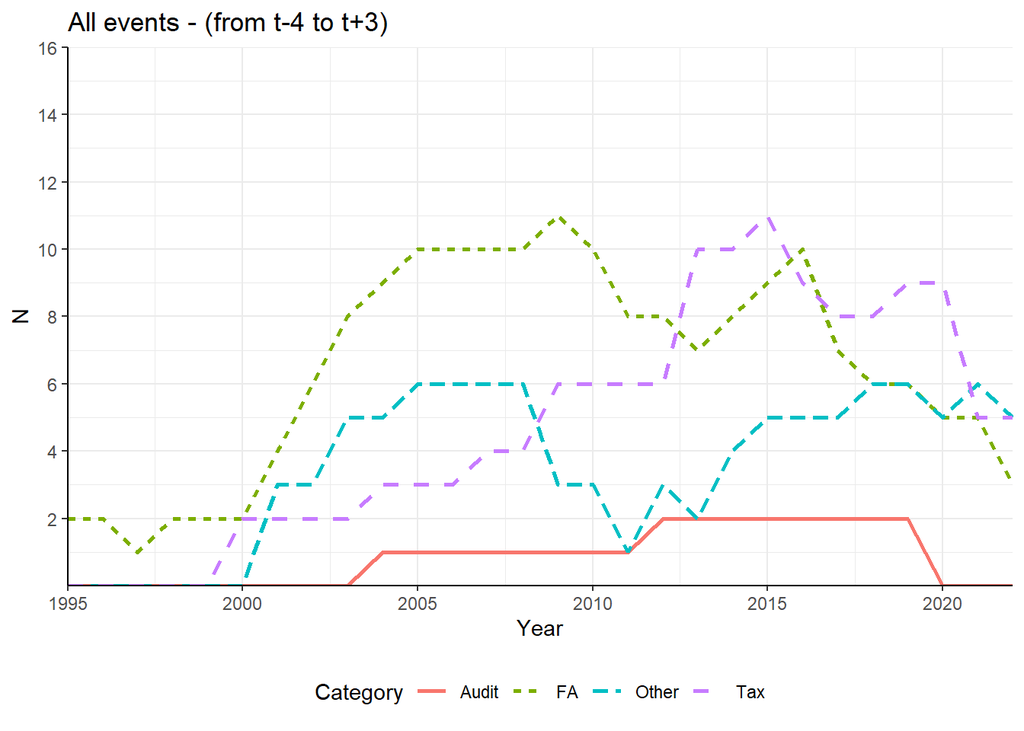

### Number of Categories

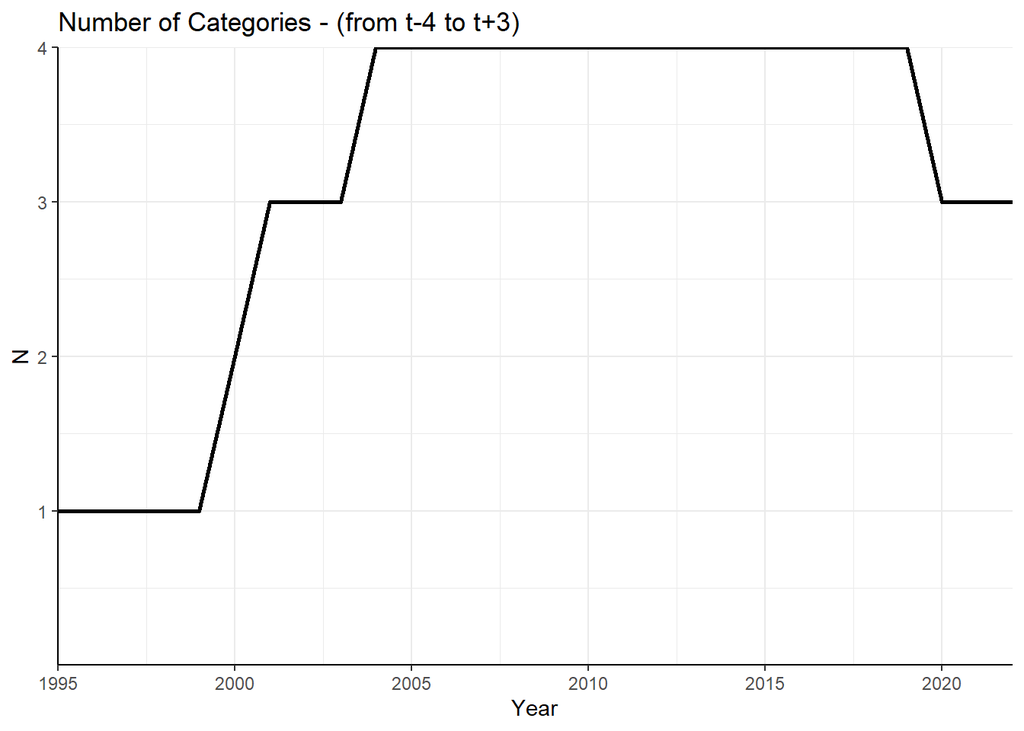

### Publications

|  | authors | title | year | journal |
| --- | --- | --- | --- | --- |
| 1 | Carnegie G.D. | the blind accountant in blindness by josé saramago and accountant stereotypes | 2021 | Accounting, Auditing and Accountability Journal |
| 2 | El-Haj M., Alves P., Rayson P., Walker M., Young S. | retrieving, classifying and analysing narrative commentary in unstructured (glossy) annual reports published as pdf files | 2020 | Accounting and Business Research |
| 3 | Robalo R.C., Moreira J.A. | the influence of power strategies in ais implementation processes | 2020 | International Journal of Accounting Information Systems |
| 4 | Leão F., Gomes D., Carnegie G.D. | the portrayal of early accountants in nineteenth century portuguese literature | 2019 | Accounting, Auditing and Accountability Journal |
| 5 | Major M., Conceição A., Clegg S. | when institutional entrepreneurship failed: the case of a responsibility centre in a portuguese hospital | 2018 | Accounting, Auditing and Accountability Journal |
| 6 | Beuselinck C., Blanco B., García Lara J.M. | the role of foreign shareholders in disciplining financial reporting | 2017 | Journal of Business Finance and Accounting |
| 7 | Isidro H., Pais C. | the role and current status of ifrs in the completion of national accounting rules–evidence from portugal | 2017 | Accounting in Europe |
| 8 | Mafrolla E., D'Amico E. | borrowing capacity and earnings management: an analysis of private loans in private firms | 2017 | Journal of Accounting and Public Policy |
| 9 | Duarte F., Matias Gama A.P., Esperança J.P. | the role of collateral in the credit acquisition process: evidence from sme lending | 2016 | Journal of Business Finance and Accounting |
| 10 | Guerreiro M.S., Rodrigues L.L., Craig R. | institutional change of accounting systems: the adoption of a regime of adapted international financial reporting standards | 2015 | European Accounting Review |

[output cut: 16 more lines]

### SSRN

|  | authors | title | Posted | Revised |
| --- | --- | --- | --- | --- |
| 1 | Vagner Marques, Lanna Nogueira, Idamo Aquino and Viviane Freitag | has it become more readable? empirical evidence of key matters in independent audit reports | 2021-07-26 | 2022-01-18 |
| 2 | Carlos F. Alves | does the latin model of corporate governance perform worse than other models in preventing earnings management? | 2020-12-29 |  |
| 3 | Carlos F. Alves | control mechanisms in the corporate governance of state-owned enterprises (soes): a comparison between brazil and portugal | 2020-12-29 |  |
| 4 | Georgina Morais and Mário Franco | deciding factors in cooperation and trust between internal and external auditors in organizations: an exploratory analysis | 2020-05-22 |  |
| 5 | Maurício Corrêa da Silva, João Carlos Hipólito Bernardes do Nascimento, José Dionisio Silva and José Ricardo Maia de Siqueira | determinantes da transparência municipal: uma análise empírica com municípios brasileiros (determinants of municipal transparency: an empirical analysis with brazilian municipalities) | 2020-03-16 |  |